> **Redacted copy for aaronsuu.github.io.** *Dataset not included: it was provided for course use only and contains sensitive responses. Notebook outputs that showed raw data have been removed.* Code and charts are unchanged; the notebook will not run without the data.

# Latent Dirichlet Allocation Notebook

This notebook file contains Python Cells that enable the user to perform Latent Dirichlet Allocaiton (LDA) on a dataset containing texts of any length. LDA is a probabilistic model originally designed to generate text. As a means to model topics/ideas in a dataset, LDA is reverse engineered to model documents (text) as a mixture of topics (e.g., it might model a document as 60% related to sports and 40% related to finance) and topics (ideas) as a mixture of words (e.g., it might model sports as 20% football, 8% soccer, etc.).

This Notebook is broken into five different Parts: Part 1: (Importing and Installing what's needed to do everything else) Part 2: Loading and Preprocessing Data (all preprocessing steps are optional -- if you would like to skip one or more preprocessing steps, simply change the column names (inside '') of the data being processed by a cell to the column name of the previous preprpocessing step. Part 3: Converting the preprocessed text data into numbers (word embedding; Part 4: Creating the LDA model and looking at the document-topic distribution (mixture of topics in each document) and topic-word distribution (mixture of words in each topic); and Part 5: Visualization and Calculating Performance

# Part 1: Importing and Installing Libraries, Functions, Modules, and Sub-Modules

```python
#Run this cell only once to enable access to functions for expanding contractions and the natural language toolkit
#these are functions and libraries that are not-standard in Python's libraries
!pip install contractions
!pip install nltk
!pip install gensim
!pip install spacy
!pip install wordcloud
```

```python
#Required for creating dataframes and handling arrays
import pandas as pd #enables use of pandas libraries with alias pd
import numpy as np #enables use of numpy libraries with alias np
import string

#Required to expand contractions
import contractions

#Required to process strings
import string

#Required for Lemmatizing
import pandas as pd
import spacy

#Required for removing stopwords
import nltk
from nltk.corpus import stopwords
nltk.download('stopwords')

#Required for word embedding either using frequency/counts method or TF-IDF method
from sklearn.feature_extraction.text import CountVectorizer
from sklearn.feature_extraction.text import TfidfVectorizer
import numpy as np
from scipy.sparse import csr_matrix

#Module required for plotting results
import matplotlib.pyplot as plt
import pandas as pd
import numpy as np
import matplotlib.pyplot as plt
from wordcloud import WordCloud, STOPWORDS
from collections import Counter
from nltk.corpus import stopwords
from nltk.util import ngrams
import nltk
import re

#Moduke required to use LDA
from sklearn.decomposition import LatentDirichletAllocation

#Module required to use LSA
from sklearn.decomposition import TruncatedSVD

#Module required to use NMF
from sklearn.decomposition import NMF

#Module for computing topic coherence
from collections import defaultdict
import math
from gensim.models.coherencemodel import CoherenceModel

#Modles required to calculate external performance metrics (compare LDA results to "known" human determined results)
from sklearn.metrics import accuracy_score, precision_score, recall_score
from sklearn.model_selection import train_test_split
from sklearn.linear_model import LogisticRegression
from sklearn.metrics import classification_report
from sklearn.metrics import confusion_matrix
```

# Part 2A: Load Data

```python
#If running this notebook file in CoLab --
#Navigate to the file folder icon on the left sidebar
#Select the file folder preceding "...", then select the content folder
#Drag the data file into the content folder

# Load dataset into a dataframe
# A dataframe is a two-dimenaional, heterogeneous data structure that acts much like a spreadsheet
# By default, Python assumes that the first row of an .xlsx or .csv file contains labels for each column
# By default, Python assigns an indext (number) to each row as a lable for that row (not including the first row)
# It is also possible to explicitly assign a column of data as the "row labels" for that dataframe
# Dataframes also allow data to be  heterogenous, meaning different columns can contain strings/text, floating point numbers, integers, etc.

import pandas as pd

#Load the Data into a datframe
import os
#Colab uses /content; locally the data sits in the 'content' folder next to this notebook
file_path = '/content/TASupport_Data.xlsx' if os.path.exists('/content/TASupport_Data.xlsx') else 'content/TASupport_Data.xlsx'
data = pd.read_excel(file_path)

#TASupport_Data.xlsx names its text column 'Document'; rename it to the name used throughout this notebook
data = data.rename(columns={'Document': 'OriginalResponse'})

#Copy the raw peer support data to another dataframe called data2
#the new dataframe data2 will contain only the raw data
#this is not a required step, but it does allow for retaining only the data of interest for this notebook
data_reduced = data[['OriginalResponse']].copy()

#Print the new dataframe to verify that it has been copied correctly
print (data_reduced)
```

# Part 2B: Preprocess Data

```python
#Remove NaNs (blank responses) and replace the dataframee with "new" data that has eliminated no responses (NaNs)
data_reduced.dropna(inplace=True)

#Excel stores line breaks as _x000D_ escape codes; replace them with spaces
data_reduced['OriginalResponse'] = data_reduced['OriginalResponse'].astype(str).str.replace('_x000D_', ' ', regex=False)

#Print Filtered Data (with NaNs removed) for Sanity Checking
print (data_reduced['OriginalResponse'])
```

```python
#Convert all text to lower case
data_reduced.loc[:, 'LowerCase'] = data_reduced['OriginalResponse'].str.lower()

#Print  Lower Case Data for Sanity Checking
print (data_reduced['LowerCase'])
```

```python
#Replace the abbreviation "ta" (and plural "tas") with "teaching assistants"
#\b makes sure only whole words are replaced (e.g., "data" and "table" are untouched)
data_reduced['TAReplaced'] = data_reduced[['LowerCase']].replace({'LowerCase': {r'\bta\b': 'teaching assistant', r'\btas\b': 'teaching assistants'}}, regex=True)['LowerCase']

#Print Data with "ta" Replaced for Sanity Checking
print (data_reduced['TAReplaced'])
```

```python
#Expand Contractions (e.g., don't becomes do not)
import contractions
#Define function that expands contractions in a single string of text
def expand_contractions_text(text):
    if isinstance(text, str):
        # contractions.fix() handles the entire string/sentence
        expanded_text = contractions.fix(text)
        return expanded_text
    return text

#Apply the function to all of the texts in "LowerCase" column of the dataframe
data_reduced['ExpandContractions'] = data_reduced['TAReplaced'].apply(expand_contractions_text)

#Print Expaneded Data for Sanity Checking
print (data_reduced['ExpandContractions'])
```

```python
#Remove Punctuation
import string
#Define function that removes punctuation in a single string of text
def remove_punctuation(text):
    """Removes punctuation from a string."""
    return ''.join([char for char in text if char not in string.punctuation])

#Apply the function to all of the texts in "ExpandContractions" column of the dataframe
data_reduced['RemovePunctuation'] = data_reduced['ExpandContractions'].apply(remove_punctuation)

#Print Data with Punctuation Removed for Sanity Checking
print (data_reduced['RemovePunctuation'])
```

```python
#Remove Special Characters

#This cell removes Special Characters from all of the texts in "RemovePunctuation" column of the dataframe
#Modify (add, remove) characters from chars_to_remove as needed/desired
chars_to_remove = '[@#$&!*]'
data_reduced['SpecialCharRemoved'] = data_reduced['RemovePunctuation'].str.replace(f'[{chars_to_remove}]', '', regex=True)

#Print Data with Special Characteristics Removed for Sanity Checking
print (data_reduced['SpecialCharRemoved'])
```

```python
#Remove Numbers

#This cell removes Numbers from all of the texts in "SpecialCharRemoved" column of the dataframe
data_reduced['NumbersRemoved'] = data_reduced['SpecialCharRemoved'].str.replace(r'\d+', '', regex=True)

#Print Data with Numbers Removed for Sanity Checking
print (data_reduced['NumbersRemoved'])
```

```python
#Lemmatize the Data using the spacy library
import pandas as pd
import spacy

# Load the lightweight English model and disable unused components for speed
#Download the model into the current kernel's environment if it is not installed yet
import subprocess, sys
try:
    nlp = spacy.load("en_core_web_sm", disable=["parser", "ner"])
except OSError:
    subprocess.check_call([sys.executable, "-m", "spacy", "download", "en_core_web_sm"])
    import importlib, en_core_web_sm
    importlib.invalidate_caches()
    nlp = en_core_web_sm.load(disable=["parser", "ner"])

# Create a sample DataFrame
#data = {"text": ["The running dogs are barking loudly.", "She ate apples yesterday."]}
#df = pd.DataFrame(data)

# Use nlp.pipe to process the entire column efficiently in batches
docs = nlp.pipe(data_reduced["NumbersRemoved"].astype(str), batch_size=50)

# Extract lemmas and join them back into strings
data_reduced["Lemmatized"] = [" ".join([token.lemma_ for token in doc]) for doc in docs]

print(data_reduced)
```

```python
#Data Preparation and Preprocessing
#Remove stopwords from the data
#Stopwords are low value words that don't add to the meaning of what is being said
#Examples are "in", "the", "an", "from"

# Define a set of default English stopwords
#default_stopwords = set(stopwords.words('english'))
stop_words = set(stopwords.words('english'))

# Name custom stopwords (in lower case)
custom_stopwords = {'student', 'professor', 'class'}

# Combine default and custom stopwords into a single set
stop = stop_words.union(custom_stopwords)

#Remove stopwords from all text in "LemmatizedData" column of the dataframe
data_reduced.loc[:, 'NoStopWords'] = data_reduced['Lemmatized'].apply(lambda x: ' '.join([word for word in x.split() if word not in (stop)]))

#Print Data with Stop Words Removed for Sanity Checking
print (data_reduced['NoStopWords'])
```

# Part 2C: Export Preprocessed Data to an MS Excel File

```python
#Print/Export Dataframe data_reduced to Excel File
#File will be located in the filepath defined previously (or alternatively a new filepath can be designated here)
#In this notebook, the exported file is placed in the "content" folder in the CoLab drive
#and needs to be downloaded before quitting the CoLab session
file_name = 'PreprocessedData.xlsx'
data_reduced.to_excel(file_name, index=False)
```

# Part 2D: Visualized the Preprocessed Data

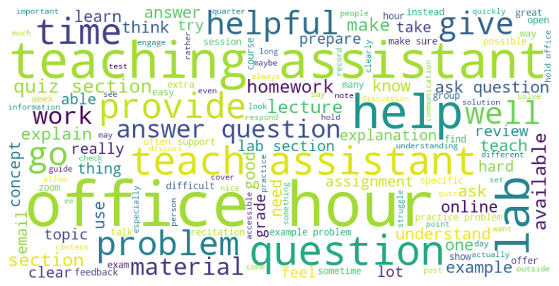

```python
#Visualize the fully preprocessed data

#Create Word Cloud for the "NoStopWords" column of the dataframew
#This column is the fully preprocessed version of the original data
text_data = ' '.join(data_reduced['NoStopWords'].fillna('').astype(str).tolist())

#Define additional stop words as necessary to remove from the word cloud
wc_stopwords = set(STOPWORDS)
#Custom Stopwords (remove as necessary to become more familiar with relevant, high-value data)
wc_stopwords.update(["nonsense", "oobla"])

#Generate the word cloud
wordcloud = WordCloud(
    width=800,
    height=400,
    background_color='white',
    stopwords = wc_stopwords,
    min_font_size=10
).generate(text_data)

#Display the generated image using matplotlib
plt.figure(figsize=(10, 5))
plt.imshow(wordcloud, interpolation='bilinear')
plt.axis("off") # Hide the axis ticks
plt.show()
```

# Part 3: Word Embedding

```python
#Choose Frequency-Counts Word Embeddding, or
#Choose TF-IDF Word Embedding

from sklearn.feature_extraction.text import CountVectorizer
from sklearn.feature_extraction.text import TfidfVectorizer
import numpy as np
from scipy.sparse import csr_matrix

#Embed Documents (document)
#min_df defines the minimum number of times a word occurs in the corpus to be embedded
#max_df defines the maximum (%) frequency a word occurs in the corpus to be embedded
#In the example below, embedding will ignore words that occur in over 80% of the doucments
#And it will ignore words that occur less than twice; these parametrs can be adjusted as needed

#Comment out the word embedding method tha tis not desired:
#Frequency/Counts embedding
#embedded_data = CountVectorizer(max_df=0.8, min_df=2,ngram_range=(1,1),stop_words='english')
#Or
#TF/IDF embedding
embedded_data = TfidfVectorizer(max_df=0.8, min_df=2,ngram_range=(1,1),stop_words='english')

doc_term = embedded_data.fit_transform(data_reduced.loc[:, 'NoStopWords'])
print ("Abbreviated matrix (includes only non-zero elements) after Embedding")
print ()
print (doc_term)
print ()

#Print entire sparse matrix
#Prints only non-zero elements of matrix
print ("Complete matrix after Embedding")
print()
print(doc_term.toarray())
```

```python
#Generate and Print embedded/vectorized vector for each word in corpus
#Useful for explanatory/learning purposes only
#Export to a file if desired to view complete, embedded corpus

#Rename original fully preprocessed corpus (before it was embedded/vectorized)
text_corpus = (data_reduced.loc[:, 'NoStopWords'])

#Get feature names (words) for each embedded/vectorized word
# Use get_feature_names_out() for recent sklearn versions
feature_names = embedded_data.get_feature_names_out()
print (feature_names)

#Convert the sparse, embedded/vectorized matrix to a dense NumPy array for viewing
# Each row represents a document, and each column represents a frequency/count score
doc_term_dense = doc_term.toarray()

#Display the words and their vector representations
print("Feature Names (Vocabulary):", feature_names)
print()
print("Vectorized Matrix (Documents as rows, words as columns):")
print()
print(doc_term_dense)

#Create a Pandas DataFrame for easier viewing
embedded_dataframe = pd.DataFrame(doc_term_dense, columns=feature_names)
print("\nDataFrame representation of the embedded words and documents:")
print ()
print(embedded_dataframe)
```

# Part 4: Generating the LDA Model and Results

```python
#Model Topics in dataset with Latent Dirichlet Allocation (LDA)

#Create empty dataframe for Results
lda_results = pd.DataFrame()

#This cell uses the document term matrix (doc_term)
#which was created in the previosu cell via word embedding
#doc-term represens the words in the dataset as numbers
#rows are documents
#columns are words in the vocabulary (i.e., all words found in the preprocessed dataset)

#Set primary model hyperparameters
n_topics = 3
default_alpha = 1/n_topics
default_beta = 1/n_topics

#Explanation of hyperparameters:
#n_components = number of topics
#doc_topics_prior = value of alpha for dirichlet distribution of documents and topics)
#small alpha leads to fewer documents having the same topics
#large alpha leads to many documents having the same topics

#topic_word_prior = value of beta for dirichelt distribution of topics and words)
#large beta leads to more words being assigned to multiple topics
#small beta leads to fewer words being assigned to multiple topics

#learning_decay = how much the learning rate decreases with each iteration of LDA (bigger value means faster convergence)
#batch_size = parameters that influneces tradeoff between speed and convergence (higher value is faster but may not converge)
#max_iter = number of interations of LDA/Bayes algorithm; default is 10

#Create LDA Model
#Adjust n_components, doc_topic_prior, topic_word_prior as needed to optimize model
LDA_model = LatentDirichletAllocation(n_components=n_topics, doc_topic_prior=default_alpha, topic_word_prior=default_beta, learning_decay=0.7, batch_size=50, max_iter=10)
LDA_model.fit(doc_term)
```

```python
#First set of LDA Results:  The top (n_top_words) words for each topic
#Each row in LDA.components_ represents a topic and the numbers in the row represent how many times a word occurs for that topic
topic_word_distributions = LDA_model.components_

#Initiate topics
k = topic_word_distributions.shape[0]
topics = [None]*k

#Map the numebrs in LDA_model.components_ back to words
feature_names = embedded_data.get_feature_names_out()#Retrieve the top (most frequently occurring) words for each topic
n_top_words = 8  # Number of top words to display per topic

#Print the n_top_words per topic
for topic_idx, topic in enumerate(topic_word_distributions):
    # Sort words by their strength in the current topic and get their indices
    top_word_indices = topic.argsort()[:-n_top_words-1:-1]
    # Map indices back to words
    top_words = [feature_names[i] for i in top_word_indices]
    topics[topic_idx] = top_words
    print(f"Topic {topic_idx}: {' '.join(top_words)}")

top_words_topics = topics[0:n_topics]
```

```python
#Second Set of LDA Results:
#Look at the probabilities that each of n_topics is represented in select documents
doc_topic_dist = LDA_model.transform(doc_term)

#doc_topic_dist' now contains the topic probabilities for each document.

#Print the probabiliteis for any desired document
#In the example below, the selected document is the first in the dataset
#Any document can be selected by changing "0" to the desired document (numbering starts at zero)
#For the first document
print("Document ", 0, "is: ", data_reduced['NoStopWords'].iloc[0])
print("and has the following probabilities:")
print (doc_topic_dist[0])

#doc_topic_dist_df = pd.DataFrame(doc_topic_dist, columns=df.columns)
doc_topic_dist_df = pd.DataFrame(doc_topic_dist)
lda_results = doc_topic_dist_df
#Label columns in lda_results
lda_results.columns = [f"Topic Probability_{i}" for i in range(len(doc_topic_dist_df.columns))]
print (lda_results)
```

```python
#Third Set of LDA Results
#Find and Print the dominant (highest probability) topic for each document:
dominant_topics = np.argmax(doc_topic_dist, axis=1)
print(dominant_topics)
lda_results['Dominant Topic'] = dominant_topics
```

```python
#Fourth Set of LDA Results
#Look at how many responses were assigned to each topic

#Assign each response to its corresponding LDA topic (by the highest probability found for each document)
topic_assignments = LDA_model.transform(doc_term)
topic_labels = np.argmax(topic_assignments, axis=1)

#Count the occurrences of each topic label
topic_counts = np.bincount(topic_labels)

#Print the number of responses in each category
for i, count in enumerate(topic_counts):
    print(f'Topic/Category {i}: {count} responses')
```

```python
#Fifth set of LDA Results:  Calculate Topic Coherence (UMass)

#Topic Coherence is an internal performance metric
#thst measures whether the top keywords assigned to a topic actually belong together logically
#Umass calculatesthe log-conditional likelihood of co-occurrence between the top words in a topic,
#It captures how often pairs of words (wi, wj) occur in the same documents (co-occurence)
#relative to how often the single word wi appears
#UMass scores are usually negative; the less negative the "better" the topic coherence

corpus_documents = data_reduced.loc[:, 'NoStopWords'].str.split()

#The following function calculates the parameters necessry to calculate UMass
def calculate_umass_coherence(topics, corpus_documents):
    """
    Calculates UMass topic coherence manually.

    Args:
        topics (list of list of str): A list where each inner list represents a topic
                                      and contains its top words.
        corpus_documents (list of list of str): A list where each inner list represents
                                                a document and contains its tokens.

    Returns:
        float: The average UMass coherence score across all topics.
    """

    # 1. Calculate D(w) and D(w_i, w_j)
    doc_freq = defaultdict(int)
    co_occurrence_freq = defaultdict(lambda: defaultdict(int))

    for doc in corpus_documents:
        unique_words_in_doc = list(set(doc)) # Consider only unique words per document for D(w) and D(w_i, w_j)
        for i, word_i in enumerate(unique_words_in_doc):
            doc_freq[word_i] += 1
            for j in range(i + 1, len(unique_words_in_doc)):
                word_j = unique_words_in_doc[j]
                co_occurrence_freq[word_i][word_j] += 1
                co_occurrence_freq[word_j][word_i] += 1 # Symmetric

    topic_coherence_scores = []
    for topic_words in topics:
        topic_pmi_sum = 0
        pair_count = 0

        # Calculate PMI for all unique pairs within the topic
        for i, word_i in enumerate(topic_words):
            for j in range(i + 1, len(topic_words)):
                word_j = topic_words[j]

                # Ensure words are in our corpus and have frequencies
                if word_i in doc_freq and word_j in doc_freq:
                    # Smoothing: Add 1 to co-occurrence if it's zero
                    co_occurrence = co_occurrence_freq[word_i][word_j]

                    # UMass uses log((D(w_i, w_j) + 1) / (D(w_i) * D(w_j)))
                    # Note: Gensim's UMass uses log((D(w_i, w_j) + 1) / D(w_i)) in some contexts,
                    # but the general formula includes D(w_j) in the denominator.
                    # The exact formula can vary slightly across implementations.

                    # For a common UMass variant, we use: log((D(w_i, w_j) + 1) / D(w_i))
                    # This is often the Gensim-like approach for UMass.
                    if doc_freq[word_i] > 0: # Avoid division by zero
                        pmi = math.log((co_occurrence + 1) / doc_freq[word_i])
                        topic_pmi_sum += pmi
                        pair_count += 1

        if pair_count > 0:
            topic_coherence_scores.append(topic_pmi_sum / pair_count)
        else:
            topic_coherence_scores.append(0) # Or handle as appropriate

    if topic_coherence_scores:
        return topic_coherence_scores, sum(topic_coherence_scores) / len(topic_coherence_scores)
        #return sum(topic_coherence_scores) / len(topic_coherence_scores)
    else:
        return 0.0
#End of Function

# Calculating UMass by Topic for a simple example
# To Sanity check the function above and also to understand better what UMass is doing
corpus_example = [
     ["apple", "banana", "fruit"],
     ["apple", "orange", "fruit"],
     ["car", "truck", "vehicle"],
     ["banana", "smoothie"],
 ]
topics_example = [
     ["apple", "banana", "fruit"],
     ["car", "truck"],
]
print ("A simple sample text dataset to demonstrate coherence:")
print ("The original documents in this sample dataset are: ", )
print (corpus_example)
print ()
print ("The top words for the two topics discovered in the sample dataset are: ",)
print (topics_example)
print ()
coherence = calculate_umass_coherence(topics_example, corpus_example)
print("UMass Topic Coherence for the two topics in the example dataset, followed by average coherence: ")
print(f"UMass Coherence {coherence}")
print ()

print ()
print ("Coherence Calculations for the data modelled by LDA in this notebook:")
print ("The top words in the topics discovered in LDA processed dataset are: ",)
print (top_words_topics)
print ()
# The following returns the Umass Coherence values for each topic and the aggregate Umass topic coherence
coherence = calculate_umass_coherence(top_words_topics, corpus_documents)
print("The UMass Coherence for the topics in the LDA processed dataset, followed by average coherence: ")
print(f"UMass Coherence {coherence}")
print ()
```

# Homework 4 (Task 1): UMass Topic Coherence vs. Number of Topics

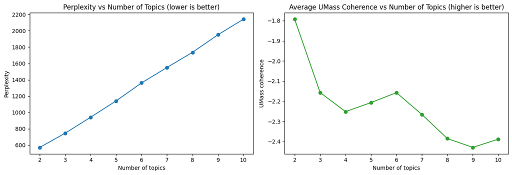

```python
#Part 6C:  Choosing the Number of Topics -- Perplexity and Coherence Curves
#Fits LDA for a range of topic counts (this cell can take a minute or two)
#Note: scikit-learn's perplexity is only a rough guide when the input is TF-IDF (not raw counts) and is
#computed on the training data, so it can rise with more topics; weigh it together with coherence.
#For raw word counts, switch Part 3 to CountVectorizer for a more meaningful perplexity.
k_values = list(range(2, 11))
perplexities, coherences = [], []

for k in k_values:
    m = LatentDirichletAllocation(n_components=k, doc_topic_prior=1/k, topic_word_prior=1/k,
                                  learning_decay=0.7, batch_size=50, max_iter=10, random_state=0)
    m.fit(doc_term)
    perplexities.append(m.perplexity(doc_term))
    top = [[feature_names[i] for i in comp.argsort()[:-n_top_words-1:-1]] for comp in m.components_]
    coherences.append(calculate_umass_coherence(top, corpus_documents)[1])

fig, axes = plt.subplots(1, 2, figsize=(13, 4.5))
axes[0].plot(k_values, perplexities, marker='o')
axes[0].set_title('Perplexity vs Number of Topics (lower is better)')
axes[0].set_xlabel('Number of topics')
axes[0].set_ylabel('Perplexity')
axes[1].plot(k_values, coherences, marker='o', color='tab:green')
axes[1].set_title('Average UMass Coherence vs Number of Topics (higher is better)')
axes[1].set_xlabel('Number of topics')
axes[1].set_ylabel('UMass coherence')
plt.tight_layout()
plt.show()

print(pd.DataFrame({'n_topics': k_values, 'perplexity': np.round(perplexities, 1), 'umass_coherence': np.round(coherences, 3)}).to_string(index=False))
print(f"Best coherence at k = {k_values[int(np.argmax(coherences))]}")
```

# Homework 4 (Part 1b): LDA Model with k = 6 Topics -- Strong vs. Weak Topic Assignments

```python
#Model Topics in dataset with Latent Dirichlet Allocation (LDA)

#Create empty dataframe for Results
lda_results = pd.DataFrame()

#This cell uses the document term matrix (doc_term)
#which was created in the previosu cell via word embedding
#doc-term represens the words in the dataset as numbers
#rows are documents
#columns are words in the vocabulary (i.e., all words found in the preprocessed dataset)

#Set primary model hyperparameters
n_topics = 6
default_alpha = 0.05
default_beta = 0.1

#Explanation of hyperparameters:
#n_components = number of topics
#doc_topics_prior = value of alpha for dirichlet distribution of documents and topics)
#small alpha leads to fewer documents having the same topics
#large alpha leads to many documents having the same topics

#topic_word_prior = value of beta for dirichelt distribution of topics and words)
#large beta leads to more words being assigned to multiple topics
#small beta leads to fewer words being assigned to multiple topics

#learning_decay = how much the learning rate decreases with each iteration of LDA (bigger value means faster convergence)
#batch_size = parameters that influneces tradeoff between speed and convergence (higher value is faster but may not converge)
#max_iter = number of interations of LDA/Bayes algorithm; default is 10

#Create LDA Model
#Adjust n_components, doc_topic_prior, topic_word_prior as needed to optimize model
LDA_model = LatentDirichletAllocation(n_components=n_topics, doc_topic_prior=default_alpha, topic_word_prior=default_beta, learning_decay=0.7, batch_size=50, max_iter=50, random_state=0)
LDA_model.fit(doc_term)
```

```python
#First set of LDA Results:  The top (n_top_words) words for each topic
#Each row in LDA.components_ represents a topic and the numbers in the row represent how many times a word occurs for that topic
topic_word_distributions = LDA_model.components_

#Initiate topics
k = topic_word_distributions.shape[0]
topics = [None]*k

#Map the numebrs in LDA_model.components_ back to words
feature_names = embedded_data.get_feature_names_out()#Retrieve the top (most frequently occurring) words for each topic
n_top_words = 8  # Number of top words to display per topic

#Print the n_top_words per topic
for topic_idx, topic in enumerate(topic_word_distributions):
    # Sort words by their strength in the current topic and get their indices
    top_word_indices = topic.argsort()[:-n_top_words-1:-1]
    # Map indices back to words
    top_words = [feature_names[i] for i in top_word_indices]
    topics[topic_idx] = top_words
    print(f"Topic {topic_idx}: {' '.join(top_words)}")

top_words_topics = topics[0:n_topics]
```

```python
#Second Set of LDA Results:
#Look at the probabilities that each of n_topics is represented in select documents
doc_topic_dist = LDA_model.transform(doc_term)

#doc_topic_dist' now contains the topic probabilities for each document.

#Print the probabiliteis for any desired document
#In the example below, the selected document is the first in the dataset
#Any document can be selected by changing "0" to the desired document (numbering starts at zero)
#For the first document
print("Document ", 0, "is: ", data_reduced['NoStopWords'].iloc[0])
print("and has the following probabilities:")
print (doc_topic_dist[0])

#doc_topic_dist_df = pd.DataFrame(doc_topic_dist, columns=df.columns)
doc_topic_dist_df = pd.DataFrame(doc_topic_dist)
lda_results = doc_topic_dist_df
#Label columns in lda_results
lda_results.columns = [f"Topic Probability_{i}" for i in range(len(doc_topic_dist_df.columns))]
print (lda_results)
```

```python
#Third Set of LDA Results
#Find and Print the dominant (highest probability) topic for each document:
dominant_topics = np.argmax(doc_topic_dist, axis=1)
print(dominant_topics)
lda_results['Dominant Topic'] = dominant_topics
```

```python
#Fourth Set of LDA Results
#Look at how many responses were assigned to each topic

#Assign each response to its corresponding LDA topic (by the highest probability found for each document)
topic_assignments = LDA_model.transform(doc_term)
topic_labels = np.argmax(topic_assignments, axis=1)

#Count the occurrences of each topic label
topic_counts = np.bincount(topic_labels)

#Print the number of responses in each category
for i, count in enumerate(topic_counts):
    print(f'Topic/Category {i}: {count} responses')
```

```python
#Fifth set of LDA Results:  Calculate Topic Coherence (UMass)

#Topic Coherence is an internal performance metric
#thst measures whether the top keywords assigned to a topic actually belong together logically
#Umass calculatesthe log-conditional likelihood of co-occurrence between the top words in a topic,
#It captures how often pairs of words (wi, wj) occur in the same documents (co-occurence)
#relative to how often the single word wi appears
#UMass scores are usually negative; the less negative the "better" the topic coherence

corpus_documents = data_reduced.loc[:, 'NoStopWords'].str.split()

#The following function calculates the parameters necessry to calculate UMass
def calculate_umass_coherence(topics, corpus_documents):
    """
    Calculates UMass topic coherence manually.

    Args:
        topics (list of list of str): A list where each inner list represents a topic
                                      and contains its top words.
        corpus_documents (list of list of str): A list where each inner list represents
                                                a document and contains its tokens.

    Returns:
        float: The average UMass coherence score across all topics.
    """

    # 1. Calculate D(w) and D(w_i, w_j)
    doc_freq = defaultdict(int)
    co_occurrence_freq = defaultdict(lambda: defaultdict(int))

    for doc in corpus_documents:
        unique_words_in_doc = list(set(doc)) # Consider only unique words per document for D(w) and D(w_i, w_j)
        for i, word_i in enumerate(unique_words_in_doc):
            doc_freq[word_i] += 1
            for j in range(i + 1, len(unique_words_in_doc)):
                word_j = unique_words_in_doc[j]
                co_occurrence_freq[word_i][word_j] += 1
                co_occurrence_freq[word_j][word_i] += 1 # Symmetric

    topic_coherence_scores = []
    for topic_words in topics:
        topic_pmi_sum = 0
        pair_count = 0

        # Calculate PMI for all unique pairs within the topic
        for i, word_i in enumerate(topic_words):
            for j in range(i + 1, len(topic_words)):
                word_j = topic_words[j]

                # Ensure words are in our corpus and have frequencies
                if word_i in doc_freq and word_j in doc_freq:
                    # Smoothing: Add 1 to co-occurrence if it's zero
                    co_occurrence = co_occurrence_freq[word_i][word_j]

                    # UMass uses log((D(w_i, w_j) + 1) / (D(w_i) * D(w_j)))
                    # Note: Gensim's UMass uses log((D(w_i, w_j) + 1) / D(w_i)) in some contexts,
                    # but the general formula includes D(w_j) in the denominator.
                    # The exact formula can vary slightly across implementations.

                    # For a common UMass variant, we use: log((D(w_i, w_j) + 1) / D(w_i))
                    # This is often the Gensim-like approach for UMass.
                    if doc_freq[word_i] > 0: # Avoid division by zero
                        pmi = math.log((co_occurrence + 1) / doc_freq[word_i])
                        topic_pmi_sum += pmi
                        pair_count += 1

        if pair_count > 0:
            topic_coherence_scores.append(topic_pmi_sum / pair_count)
        else:
            topic_coherence_scores.append(0) # Or handle as appropriate

    if topic_coherence_scores:
        return topic_coherence_scores, sum(topic_coherence_scores) / len(topic_coherence_scores)
        #return sum(topic_coherence_scores) / len(topic_coherence_scores)
    else:
        return 0.0
#End of Function

# Calculating UMass by Topic for a simple example
# To Sanity check the function above and also to understand better what UMass is doing
corpus_example = [
     ["apple", "banana", "fruit"],
     ["apple", "orange", "fruit"],
     ["car", "truck", "vehicle"],
     ["banana", "smoothie"],
 ]
topics_example = [
     ["apple", "banana", "fruit"],
     ["car", "truck"],
]
print ("A simple sample text dataset to demonstrate coherence:")
print ("The original documents in this sample dataset are: ", )
print (corpus_example)
print ()
print ("The top words for the two topics discovered in the sample dataset are: ",)
print (topics_example)
print ()
coherence = calculate_umass_coherence(topics_example, corpus_example)
print("UMass Topic Coherence for the two topics in the example dataset, followed by average coherence: ")
print(f"UMass Coherence {coherence}")
print ()

print ()
print ("Coherence Calculations for the data modelled by LDA in this notebook:")
print ("The top words in the topics discovered in LDA processed dataset are: ",)
print (top_words_topics)
print ()
# The following returns the Umass Coherence values for each topic and the aggregate Umass topic coherence
coherence = calculate_umass_coherence(top_words_topics, corpus_documents)
print("The UMass Coherence for the topics in the LDA processed dataset, followed by average coherence: ")
print(f"UMass Coherence {coherence}")
print ()
```

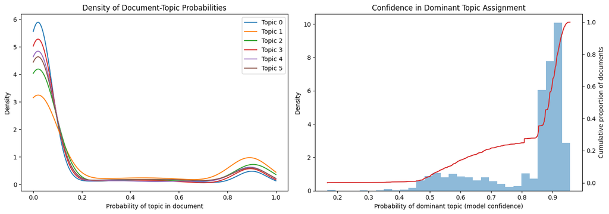

```python
#Part 6A:  Distribution Curves of the Document-Topic Probabilities
from scipy import stats

prob_cols = [c for c in lda_results.columns if c.startswith('Topic Probability_')]
n_t = len(prob_cols)

fig, axes = plt.subplots(1, 2, figsize=(14, 5))

#Left: kernel density curve of the probability each document has for each topic
x_grid = np.linspace(0, 1, 200)
for col in prob_cols:
    vals = lda_results[col].values
    axes[0].plot(x_grid, stats.gaussian_kde(vals)(x_grid), label=col.replace('Topic Probability_', 'Topic '))
axes[0].set_title('Density of Document-Topic Probabilities')
axes[0].set_xlabel('Probability of topic in document')
axes[0].set_ylabel('Density')
axes[0].legend()

#Right: histogram and cumulative curve of the model's confidence (highest topic probability per document)
max_prob = lda_results[prob_cols].max(axis=1).values
axes[1].hist(max_prob, bins=30, density=True, alpha=0.5, color='tab:blue', label='Histogram')
axes[1].set_xlabel('Probability of dominant topic (model confidence)')
axes[1].set_ylabel('Density')
ax2 = axes[1].twinx()
ax2.plot(np.sort(max_prob), np.arange(1, len(max_prob) + 1) / len(max_prob), color='tab:red', label='Cumulative')
ax2.set_ylabel('Cumulative proportion of documents')
axes[1].set_title('Confidence in Dominant Topic Assignment')
plt.tight_layout()
plt.show()

print("Confidence (dominant topic probability) summary:")
print(pd.Series(max_prob).describe().round(3))
print(f"Share of documents with dominant-topic probability > 0.6: {(max_prob > 0.6).mean():.1%}")
```

```python
#Export LDA Results

#This cell assigns only a number to each document corresponding to a particular topic
#Interpretation of the topics must be done manually in the output file or with an additional cell

import numpy as np
import pandas as pd

#Create Output Dataframe consisting of Original Response and the Topic assigned to each Response

#Reset indices for original responses in data_reducedd
temp1_df = data_reduced.reset_index(drop=True)
temp2_df = temp1_df['OriginalResponse']
#TASupport_Data.xlsx has no human-assigned theme column, so include it only if present
temp3_df = data['AssignedTheme1'] if 'AssignedTheme1' in data.columns else None
#temp4_df = pd.DataFrame(topic_labels, columns=['AssignedTopic'])
output_df = pd.concat([x for x in (temp2_df, temp3_df, lda_results) if x is not None], axis=1)

#xport Output Dataframe to MS Excel
file_name = 'Results.xlsx'
output_df.to_excel(file_name, index=False)
```